# Final_project

Siya Qiu & Shuhan Song

12/3/2019

##### **1. What makes voter behavior prediction (and thus election forecasting) a hard problem?**

##### **2. What was unique to Nate Silver’s approach in 2012 that allowed him to achieve good predictions?**

##### **3. What went wrong in 2016? What do you think should be done to make future predictions better?**

##### 4. Report the dimention of election.raw after removing rows with fips = 2000. Provide a reason for excluding them. Please make sure to use the same name election.raw before and after removing those observations.

- The dataset “election.raw” is comprised by data from three levels: country-level data, state-level data, and federal_level data. For country-level data, the dataset should show its FIPS (Federal Information Processing Standard) in the “fips” column, as well as the specific county name in the “county” column. However, for observations with “fips” equals to “2000”, they do not have their county name specified in the “county” column. In order to protect the consistency of our data, we need to remove data with “fips” equal to “2000”.  
  After removal, the “election.raw” dataset now has 18351 observations and 5 variables.

##### 5. Remove summary rows from election.raw data

##### 6. How many named presidential candidates were there in the 2016 election? Draw a bar chart of all votes received by each candidate. You can split this into multiple plots or may prefer to plot the results on a log scale. Either way, the results should be clear and legible!

- There are 32 categories of candidates in the 2016 election, in which 31 are refering to specific person and 1 category is for “None of these candidates”.

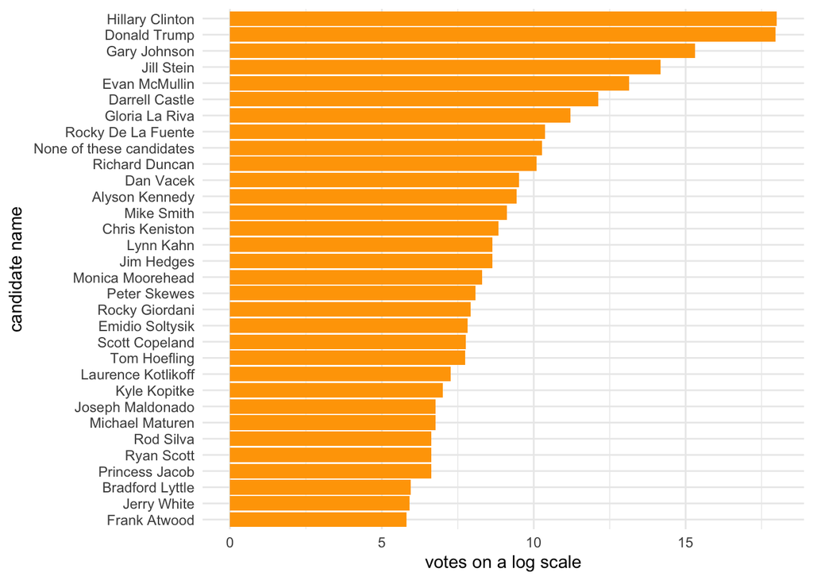

##### 7. Create variables county_winner and state_winner by taking the candidate with the highest proportion of votes. Hint: to create country_winner, start with election, group_by fips, compute total votes, and pct = votes/total. Then choose the highest row using top_n(variable state)winner is similar).

##### 8. Draw county-level map by creating counties = map_data(“county”). Color by county.

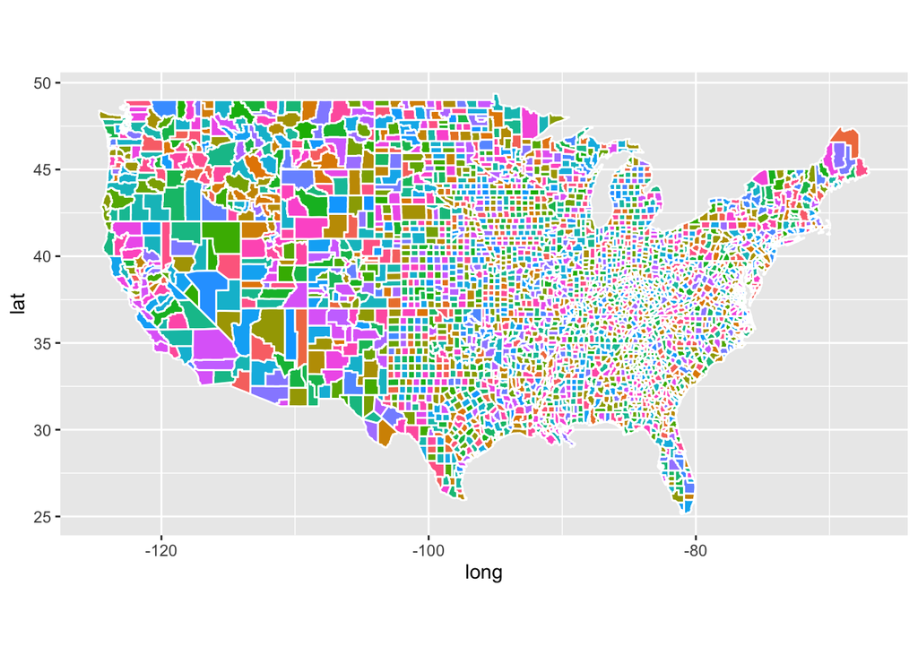

##### 9. Now color the map by the winning candidate for each state.

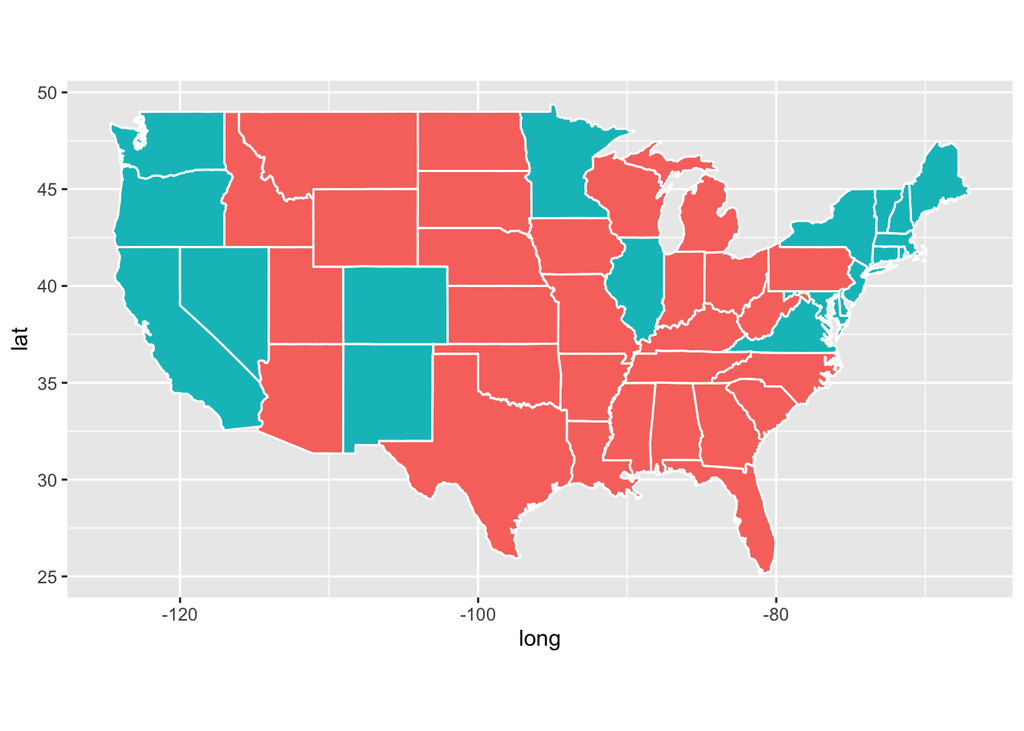

##### 10. The variable county does not have fips column. So we will create one by pooling information from maps::county.fips. Split the polyname column to region and subregion. Use left_join() combine county.fips into county. Also, left_join() previously created variable county_winner

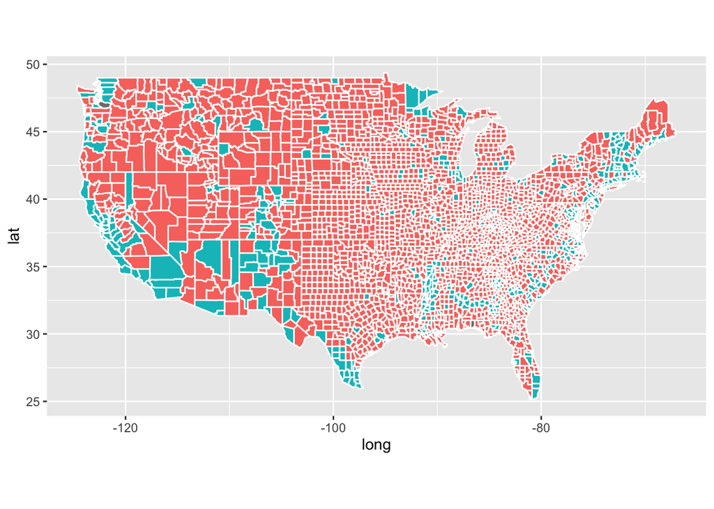

##### 11. Create a visualization of your choice using census data.

- The map shows the percentage of poverty in each state and how it may relate to the election result. As it shows in the map, states with higher percentage of poverty tend to vote for Donald Trump (filled as red), while states with lower percentage of poverty tend to vote for 13 Hillary Clinton (filled as green)

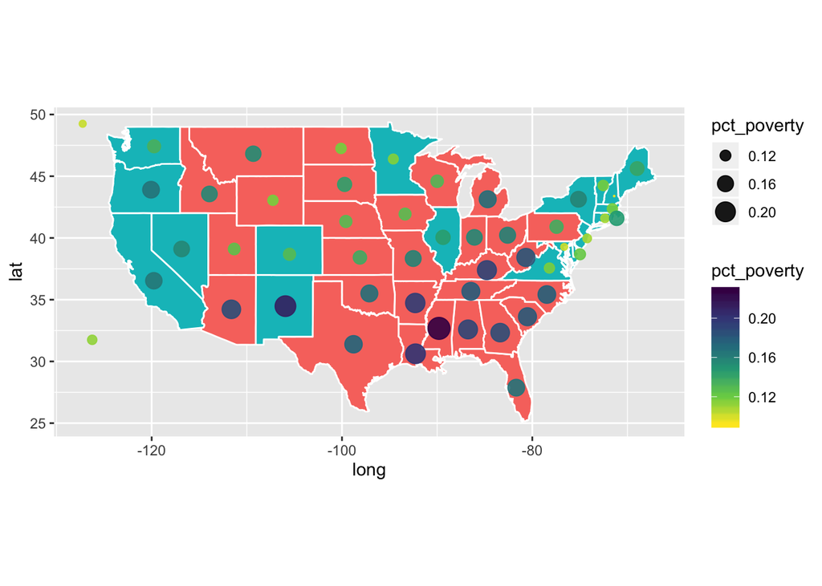

##### 12. The census data contains high resolution information (more fine-grained than county-level). In this problem, we aggregate the information into county-level data by computing TotalPop-weighted average of each attributes for each county.

- Here is some example after information aggregating

| State | County | TotalPop | Men | Women | White | Citizen | Income | IncomeErr | IncomePerCap | IncomePerCapErr | Poverty | ChildPoverty | Professional | Service | Office | Production | Drive | Carpool | Transit | OtherTransp | WorkAtHome | MeanCommute | Employed | PrivateWork | SelfEmployed | FamilyWork | Unemployment | minority |
| --- | --- | --- | --- | --- | --- | --- | --- | --- | --- | --- | --- | --- | --- | --- | --- | --- | --- | --- | --- | --- | --- | --- | --- | --- | --- | --- | --- | --- |
| Alabama | Autauga | 55221 | 48.43266 | 3348.805 | 75.78823 | 73.74912 | 51696.29 | 7771.009 | 24974.50 | 3433.674 | 12.91231 | 18.70758 | 32.79097 | 17.17044 | 24.28243 | 17.15713 | 87.50624 | 8.781235 | 0.0952590 | 1.3059687 | 1.8356531 | 26.50016 | 0.4343637 | 73.73649 | 5.433254 | 0.0000000 | 7.733726 | 22.53687 |
| Alabama | Baldwin | 195121 | 48.84866 | 3934.167 | 83.10262 | 75.69406 | 51074.36 | 8745.050 | 27316.84 | 3803.718 | 13.42423 | 19.48431 | 32.72994 | 17.95092 | 27.10439 | 11.32186 | 84.59861 | 8.959078 | 0.1266209 | 1.4438000 | 3.8504774 | 26.32218 | 0.4405113 | 81.28266 | 5.909353 | 0.3633269 | 7.589820 | 15.21426 |
| Alabama | Barbour | 26932 | 53.82816 | 1491.941 | 46.23159 | 76.91222 | 32959.30 | 6031.065 | 16824.22 | 2430.189 | 26.50563 | 43.55962 | 26.12404 | 16.46343 | 23.27878 | 23.31741 | 83.33021 | 11.056609 | 0.4954032 | 1.6217251 | 1.5019456 | 24.51828 | 0.3192113 | 71.59426 | 7.149837 | 0.0897742 | 17.525557 | 51.94382 |
| Alabama | Bibb | 22604 | 53.41090 | 2930.106 | 74.49989 | 77.39781 | 38886.63 | 5662.358 | 18430.99 | 3073.599 | 16.60375 | 27.19708 | 21.59010 | 17.95545 | 17.46731 | 23.74415 | 83.43488 | 13.153641 | 0.5031366 | 1.5620952 | 0.7314679 | 28.71439 | 0.3669262 | 76.74385 | 6.637936 | 0.3941515 | 8.163104 | 24.16597 |
| Alabama | Blount | 57710 | 49.40565 | 3562.081 | 87.85385 | 73.37550 | 46237.97 | 8695.786 | 20532.27 | 2052.055 | 16.72152 | 26.85738 | 28.52930 | 13.94252 | 23.83692 | 20.10413 | 84.85031 | 11.279222 | 0.3626321 | 0.4199411 | 2.2654133 | 34.84489 | 0.3844914 | 81.82671 | 4.228716 | 0.3564928 | 7.699640 | 10.59474 |

##### 13. Run PCA for both county & sub-county level data. Save the first two principle components PC1 and PC2 into a two-column data frame, call it ct.pc and subct.pc, respectively. Discuss whether you chose to center and scale the features before running PCA and the reasons for your choice. What are the three features with the largest absolute values of the first principal component? Which features have opposite signs and what does that mean about the correaltion between these features?

- We checked the variables in the dataframe that their variances are vastly different from each other. If we do not center and scale the variables before performing PCA, then most of the PC that we observed would be driven by variables that have the largest variances. Thus, it is important to standardize the variables to have mean zero and sd of 1 beforming PCA [1].  
  [1] James et. al. - An Introduction to Statistical Learning with Applications in R, Eigth Edition. Available at: http://www-bcf.usc.edu/~gareth/ISL/
- The three features with the largest absolute values of the first principal component from the sub-county level data are: IncomePerCap, Professional, and Poverty.
- The three features with the largest absolute values of the first principal component from the county level data are: IncomePerCap, ChildPoverty, and Poverty.
- The negative feature of the largest 3 subcounty feature is: Poverty.
- The negative feature of the largest 3 county feature is: ChildPoverty, Poverty.
- The negative sign means that Poverty affect the election result in an opposite direction comparing to other features

##### 14. Determine the number of minimum number of PCs needed to capture 90% of the variance for both the county and sub-county analyses.

- See the following two plots for PVE and cumulative PVE for sub-county level data.
- As shown in the second plot, the Cumulative Proportion of Variance Explained, we need at least 16 PCs to capture 90% of the variance in the sub-county level analyses.

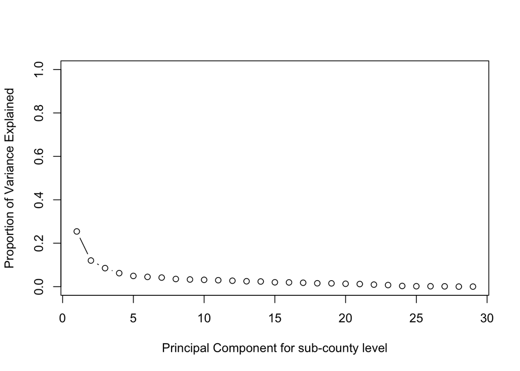

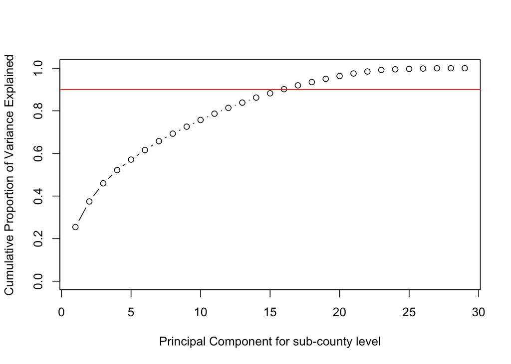

- See the following two plots for PVE and cumulative PVE for county-level data
- As shown in the second plot, the Cumulative Proportion of Variance Explained, we need at least 14 PCs to capture 90% of the variance in the county-level analyses.

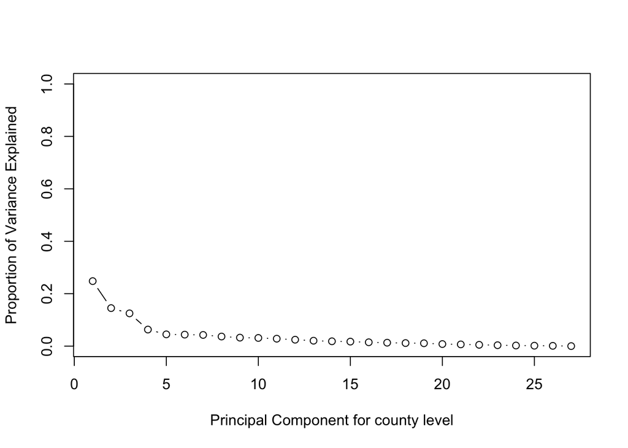

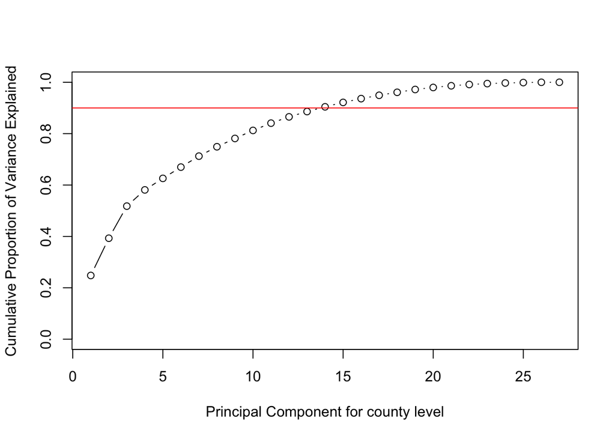

##### 15. With census.ct, perform hierarchical clustering with complete linkage. Cut the tree to partition the observations into 10 clusters. Re-run the hierarchical clustering algorithm using the first 5 principal components of ct.pc as inputs instead of the originald features. Compare and contrast the results. For both approaches investigate the cluster that contains San Mateo County. Which approach seemed to put San Mateo County in a more appropriate clusters? Comment on what you observe and discuss possible explanations for these observations.

- The two trees does not agree with each other. The 5 PC tree dissipate observations in the first cluster of the original tree to clusters 1 to 7.
- See the following table for the contract result. Each column represents for the number of observation assigned to each cluster in the 5 PC tree. Each row represents for the number of observation assigned to each cluster in the original tree.

  |  | 1 | 2 | 3 | 4 | 5 | 6 | 7 | 8 | 9 | 10 |
  | --- | --- | --- | --- | --- | --- | --- | --- | --- | --- | --- |
  | 1 | 1913 | 566 | 166 | 86 | 74 | 8 | 132 | 0 | 4 | 8 |
  | 2 | 21 | 0 | 1 | 39 | 0 | 0 | 0 | 6 | 2 | 0 |
  | 3 | 89 | 0 | 3 | 60 | 0 | 0 | 0 | 1 | 0 | 0 |
  | 4 | 0 | 0 | 0 | 2 | 0 | 0 | 0 | 0 | 0 | 0 |
  | 5 | 1 | 0 | 0 | 16 | 0 | 0 | 0 | 2 | 1 | 0 |
  | 6 | 0 | 0 | 0 | 0 | 0 | 0 | 0 | 1 | 0 | 0 |
  | 7 | 0 | 0 | 0 | 2 | 0 | 0 | 0 | 0 | 0 | 0 |
  | 8 | 2 | 0 | 0 | 7 | 0 | 0 | 0 | 1 | 0 | 0 |
  | 9 | 0 | 0 | 0 | 2 | 0 | 0 | 0 | 1 | 0 | 0 |
  | 10 | 0 | 0 | 0 | 0 | 0 | 0 | 0 | 1 | 0 | 0 |

- The original tree contains San Mateo County in cluster 2.
- The 5 PC tree contains San Mateo County in cluster 4.
- The five PC approch seems to put San Mateo County in a more appropriate clusters. Firstly, if we look at the cumulative PVE plot, 5 PC together can explain more than 60% of the variance. Secondly, the PC approach removed coorelation between variables, which is a good supplement to clustering. Thirdly, the county winner of San Mateo County is Hillary Clinton, which is more consistant with other counties within the same cluster for the 5PCapproach.

###### 16. Decision tree: train a decision tree by cv.tree(). Prune tree to minimize misclassification error. Be sure to use the folds from above for cross-validation. Visualize the trees before and after pruning. Save training and test errors to records variable. Intepret and discuss the results of the decision tree analysis.

- Tree before pruning

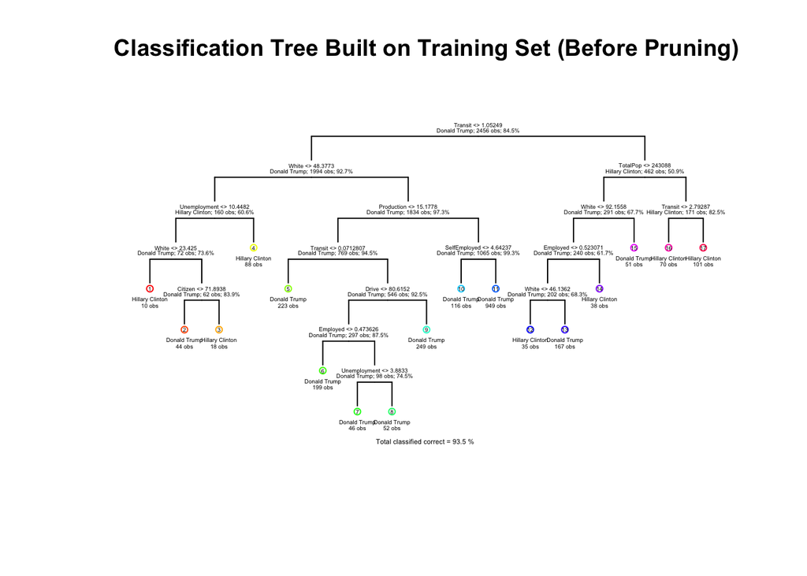

- Tree after pruning

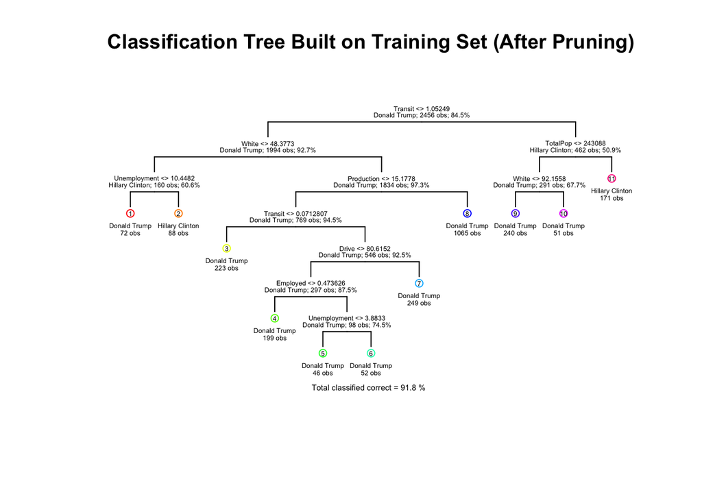

- The training error of decision tree is 0.0822476, while the testing error is 0.0780488. The training error and testing error are close to each other, and both errors are relatively small. This means that our training model does not overfit the training data and will correctly predict the election results at a rate of 92.195122%.

  |  | train.error | test.error |
  | --- | --- | --- |
  | tree | 0.0822476 | 0.0780488 |
  | logistic | NA | NA |
  | lasso | NA | NA |

##### 17. Run a logistic regression to predict the winning candidate in each county. Save training and test errors to records variable. What are the significant variables? Are the consistent with what you saw in decision tree analysis? Interpret the meaning of a couple of the significant coefficients in terms of a unit change in the variables.

|  | train.error | test.error |
| --- | --- | --- |
| tree | 0.0822476 | 0.0780488 |
| logistic | 0.0700326 | 0.0650407 |
| lasso | NA | NA |

##### 19. Compute ROC curves for the decision tree, logistic regression and LASSO logistic regression using predictions on the test data.

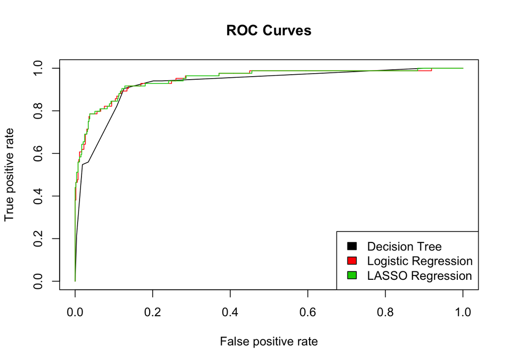

##### 20. This is an open question. Interpret and discuss any overall insights gained in this analysis and possible explanations.

- Here, we want to use random forest and boosting to do classifications, and compare the two methods

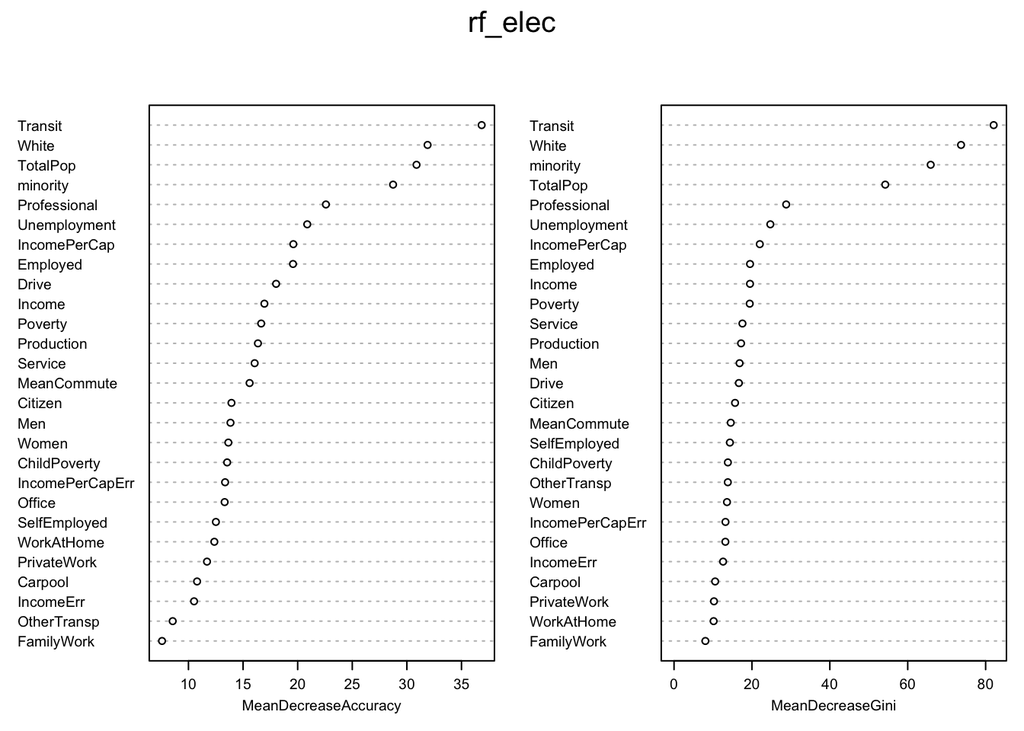

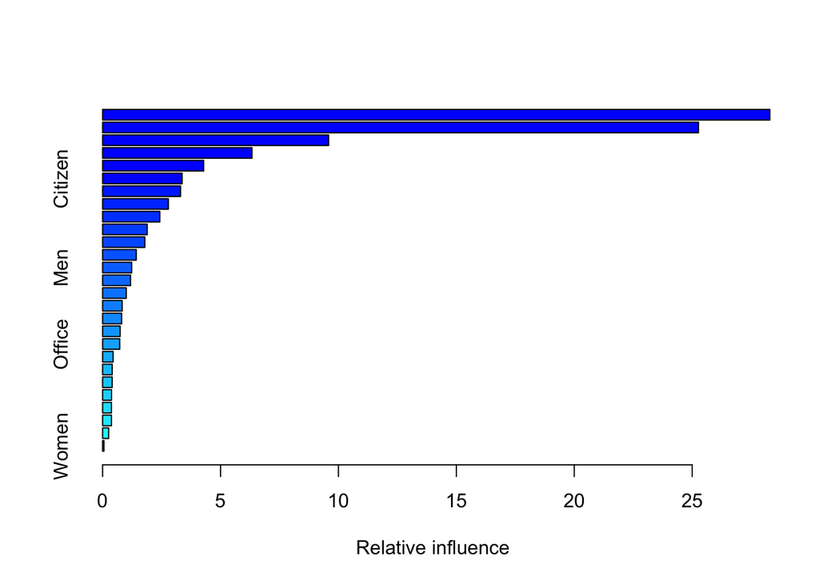